--- ---

# Exploring Some Pair-Trading Concepts with Python

**Resources**

- [YouTube Companion Video](https://www.youtube.com/watch?v=flFLco2Iuoc&list=UUq4pm1i_VZqxKVVOz5qRBIA&index=1)

[figure not shown]

In this post, I want to share some simple ways of comparing stocks that are presumed related. My recommended approach for finding related companies is to use your own domain expertise. The second option is to use a site based on fundamental analysis that shows related companies (Google it, they’re lots out there like tipranks.com). I don’t recommend using pair-trading scanners as you’ll lose your shirt if you aren’t knowledgeable about the stock and sector - trader beware!

Once you have a few stocks in mind, you’re good to continue on with this exercise. Here we will use the ‘pair-trading’ classics of Coca-Cola vs. Pepsi, and FedEx vs. UPS.

*Note: Everything discussed here is for educational purposes only.*

```python
import glob, os
import pandas as pd
import numpy as np
import matplotlib.pyplot as plt
import matplotlib.dates as mdates
```

**Load market data for FDX, UPS, KO, PEP**

There are plenty of sources to get free stock market data, Yahoo Finance is one of them. But all those who will want to do some serious research in this area should not rely on free data. You will eventually need a safe, reliable and currated source of stock data - no shortcuts here.

https://finance.yahoo.com/quote/FDX/history?p=FDX

And then find and click the "Download Data" link, it will default to one year of end-of-day market data. Run through this process for all four stocks listed in the title and save the four CSV files in a directory named 'data'.

```python
# find the data directory and extract each CSV file
path = "data/"
allFiles = glob.glob(os.path.join(path, "*.csv"))
np_array_list = []
for file_ in allFiles:
    df = pd.read_csv(file_,index_col=None, header=0)
    # get symbol name from file
    df['Symbol'] = (file_.split('/')[1]).split(".")[0]
    # pull only needed fields
    df = df[['Symbol','Date', 'Adj Close']]
    np_array_list.append(df.as_matrix())

# stack all arrays and tranfer it into a data frame
comb_np_array = np.vstack(np_array_list)
# simplify column names
stock_data_raw = pd.DataFrame(comb_np_array, columns = ['Symbol','Date', 'Close'])
# fix datetime data
stock_data_raw['Date'] = pd.to_datetime(stock_data_raw['Date'], infer_datetime_format=True)
stock_data_raw['Date'] = stock_data_raw['Date'].dt.date

# check for NAs
stock_data_raw = stock_data_raw.dropna(axis=1, how='any')

# quick hack to get the column names (i.e. whatever stocks you loaded)
stock_data_tmp = stock_data_raw.copy()

# make symbol column header
stock_data_raw = stock_data_raw.pivot('Date','Symbol')
stock_data_raw.columns = stock_data_raw.columns.droplevel()
# collect correct header names (actual stocks)
column_names = list(stock_data_raw)

stock_data_raw.tail()
```

| Symbol Date | FDX | KO | PEP | UPS |
| --- | --- | --- | --- | --- |
| 2018-07-11 | 230.22 | 44.79 | 112.54 | 107.33 |
| 2018-07-12 | 232.69 | 44.67 | 111.53 | 108.53 |
| 2018-07-13 | 233.75 | 44.74 | 112.69 | 108.97 |
| 2018-07-16 | 230.18 | 44.73 | 112.96 | 110.65 |
| 2018-07-17 | 231.15 | 45.25 | 114.88 | 111.07 |

```python
# hack to remove mult-index stuff
stock_data_raw = stock_data_tmp[['Symbol', 'Date', 'Close']]
stock_data_raw = stock_data_raw.pivot('Date','Symbol')
stock_data_raw.columns = stock_data_raw.columns.droplevel(-1)
stock_data_raw.columns = column_names

# replace NaNs with previous value
stock_data_raw.fillna(method='bfill', inplace=True)

stock_data_raw.tail()
```

| Date | FDX | KO | PEP | UPS |
| --- | --- | --- | --- | --- |
| 2018-07-11 | 230.220001 | 44.790001 | 112.540001 | 107.330002 |
| 2018-07-12 | 232.690002 | 44.669998 | 111.529999 | 108.529999 |
| 2018-07-13 | 233.750000 | 44.740002 | 112.690002 | 108.970001 |
| 2018-07-16 | 230.179993 | 44.730000 | 112.959999 | 110.650002 |
| 2018-07-17 | 231.149994 | 45.250000 | 114.879997 | 111.070000 |

Make a copy of the data set before transforming it

```python
stock_data = stock_data_raw.copy()
```

**Plot paired stocks on different axes**

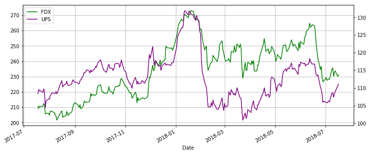

```python
plt.figure(figsize=(12,5))
ax1 = stock_data['FDX'].plot(color='green', grid=True, label='FDX')
ax2 = stock_data['UPS'].plot(color='purple', grid=True, secondary_y=True, label='UPS')
h1, l1 = ax1.get_legend_handles_labels()
h2, l2 = ax2.get_legend_handles_labels()

plt.legend(h1+h2, l1+l2, loc=2)
plt.show()
```

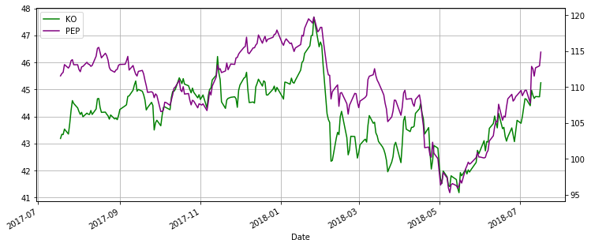

```python
plt.figure(figsize=(12,5))
ax1 = stock_data['KO'].plot(color='green', grid=True, label='KO')
ax2 = stock_data['PEP'].plot(color='purple', grid=True, secondary_y=True, label='PEP')
h1, l1 = ax1.get_legend_handles_labels()
h2, l2 = ax2.get_legend_handles_labels()

plt.legend(h1+h2, l1+l2, loc=2)
plt.show()
```

**Normalize data**

In order to compare moves between differently priced assets, we need to normalize the data.

According to Wikipedia,

> In statistics and applications of statistics, normalization can have a range of meanings. In the simplest cases, normalization of ratings means adjusting values measured on different scales to a notionally common scale, often prior to averaging.

https://en.wikipedia.org/wiki/Normalization_(statistics)

*Percent Change And Cumsum*

A very simple way to do this is to transform price data into percentage changes and apply a rolling sum, known as a cumulative sum.

```python
def normalize_and_accumulate_series(data):
    # take tail to drop head NA
    return data.pct_change().cumsum()

stock_data['FDX'] = normalize_and_accumulate_series(stock_data['FDX'])
stock_data['UPS'] = normalize_and_accumulate_series(stock_data['UPS'])
stock_data['KO'] = normalize_and_accumulate_series(stock_data['KO'])
stock_data['PEP'] = normalize_and_accumulate_series(stock_data['PEP'])

# remove first row with NAs
stock_data = stock_data.tail(len(stock_data)-1)
```

```python
stock_data.head()
```

| Date | FDX | KO | PEP | UPS |
| --- | --- | --- | --- | --- |
| 2017-07-19 | 0.008719 | 0.003582 | 0.002869 | 0.010373 |
| 2017-07-20 | 0.004021 | 0.003359 | 0.004343 | 0.006744 |
| 2017-07-21 | 0.006995 | 0.008044 | 0.014039 | 0.007632 |
| 2017-07-24 | 0.007795 | 0.003825 | 0.009752 | 0.002929 |
| 2017-07-25 | 0.015741 | 0.012745 | 0.012508 | 0.012470 |

**Plot paired stocks on same axes**

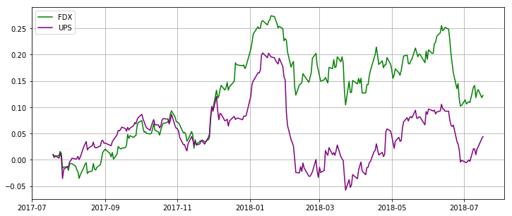

```python
fig, ax = plt.subplots(figsize=(12,5))
plt.plot(stock_data['FDX'], color='green', label='FDX')
plt.plot(stock_data['UPS'], color='purple', label='UPS')
ax.grid(True)
plt.legend(loc=2)
plt.show()
```

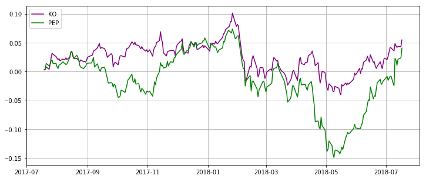

```python
fig, ax = plt.subplots(figsize=(12,5))
plt.plot(stock_data['KO'], color='purple', label='KO')
plt.plot(stock_data['PEP'], color='green', label='PEP')
ax.grid(True)
plt.legend(loc=2)
plt.show()
```

**Getting some statistical measurements**

```python
# pip install scipy
# pip install statsmodels
from statsmodels.tsa.stattools import coint

def corr(data1, data2):
    "data1 & data2 should be numpy arrays."
    mean1 = data1.mean()
    mean2 = data2.mean()
    std1 = data1.std()
    std2 = data2.std()
    corr = ((data1*data2).mean()-mean1*mean2)/(std1*std2)
    return corr
```

```python
stock_name_1 = 'KO'
stock_name_2 = 'PEP'

score, pvalue, _ = coint(stock_data[stock_name_1], stock_data[stock_name_2])
correlation = corr(stock_data[stock_name_1], stock_data[stock_name_2])

print('Correlation between %s and %s is %f' % (stock_name_1, stock_name_2, correlation))
print('Cointegration between %s and %s is %f' % (stock_name_1, stock_name_2, pvalue))
```

```
Correlation between KO and PEP is 0.798133
Cointegration between KO and PEP is 0.036950
```

```python
stock_name_1 = 'UPS'
stock_name_2 = 'FDX'

score, pvalue, _ = coint(stock_data[stock_name_1], stock_data[stock_name_2])
correlation = corr(stock_data[stock_name_1], stock_data[stock_name_2])

print('Correlation between %s and %s is %f' % (stock_name_1, stock_name_2, correlation))
print('Cointegration between %s and %s is %f' % (stock_name_1, stock_name_2, pvalue))
```

```
Correlation between UPS and FDX is 0.454536
Cointegration between UPS and FDX is 0.210379
```

**Measuring separatation and spikes highlights**

This is straighforward, we simply subtract the two related and normalized series

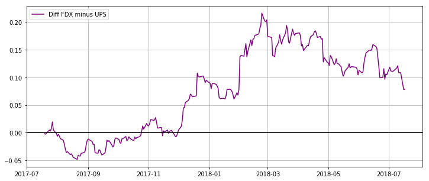

```python
fig, ax = plt.subplots(figsize=(12,5))
plt.plot(stock_data['FDX'] - stock_data['UPS'], color='purple', label='Diff FDX minus UPS')
ax.grid(True)
ax.axhline(y=0, color='black', linestyle='-')
plt.legend(loc=2)
plt.show()
```

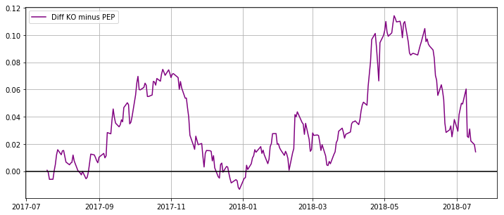

```python
fig, ax = plt.subplots(figsize=(12,5))
plt.plot(stock_data['KO'] - stock_data['PEP'], color='purple', label='Diff KO minus PEP')
ax.grid(True)
ax.axhline(y=0, color='black', linestyle='-')
plt.legend(loc=2)
plt.show()
```

Designing spike thresholds

```python
# get the original data set
stock_data = stock_data_raw.copy()
```

```python
def normalize_series(data):
    # take tail to drop head NA
    return data.pct_change()

stock_data['FDX'] = normalize_series(stock_data['FDX'])
stock_data['UPS'] = normalize_series(stock_data['UPS'])
stock_data['KO'] = normalize_series(stock_data['KO'])
stock_data['PEP'] = normalize_series(stock_data['PEP'])

# remove first row with NAs
stock_data = stock_data.tail(len(stock_data)-1)
```

```python
stock_data.head()
```

| Date | FDX | KO | PEP | UPS |
| --- | --- | --- | --- | --- |
| 2017-07-19 | 0.008719 | 0.003582 | 0.002869 | 0.010373 |
| 2017-07-20 | -0.004697 | -0.000223 | 0.001474 | -0.003629 |
| 2017-07-21 | 0.002973 | 0.004685 | 0.009696 | 0.000888 |
| 2017-07-24 | 0.000800 | -0.004219 | -0.004287 | -0.004703 |
| 2017-07-25 | 0.007946 | 0.008921 | 0.002756 | 0.009541 |

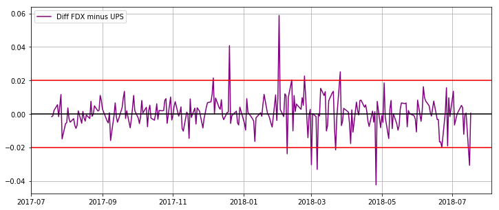

```python
fig, ax = plt.subplots(figsize=(12,5))
plt.plot(stock_data['FDX'] - stock_data['UPS'], color='purple', label='Diff FDX minus UPS')
ax.grid(True)
ax.axhline(y=0, color='black', linestyle='-')
ax.axhline(y=0.02, color='red', linestyle='-')
ax.axhline(y=-0.02, color='red', linestyle='-')
plt.legend(loc=2)
plt.show()
```

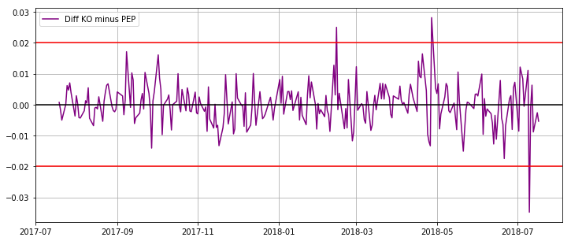

```python
fig, ax = plt.subplots(figsize=(12,5))
plt.plot(stock_data['KO'] - stock_data['PEP'], color='purple', label='Diff KO minus PEP')
ax.grid(True)
ax.axhline(y=0, color='black', linestyle='-')
ax.axhline(y=0.02, color='red', linestyle='-')
ax.axhline(y=-0.02, color='red', linestyle='-')
plt.legend(loc=2)
plt.show()
```

Manuel Amunategui - Follow me on Twitter: @amunategui